# IST_719_HW7

Kendra Osburn

5/27/2019

## QUESTION 1

### Recreate the boxplot using ggplot.

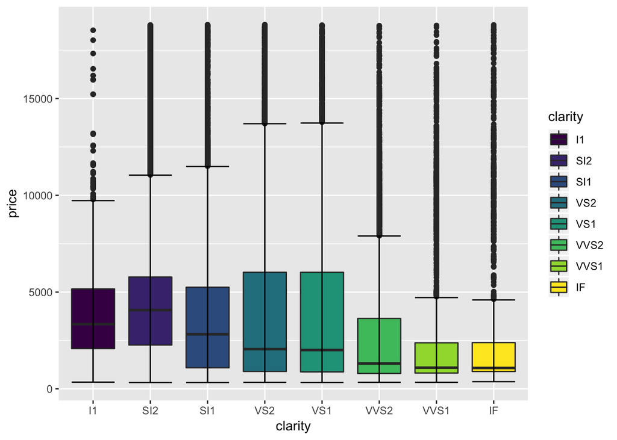

```r
library(ggplot2)
ggplot(diamonds, aes(clarity, price, fill = clarity)) +
  geom_boxplot() +
  stat_boxplot(geom = 'errorbar')
```

## QUESTION 2

## Recreate the boxplot to show caret by clarity

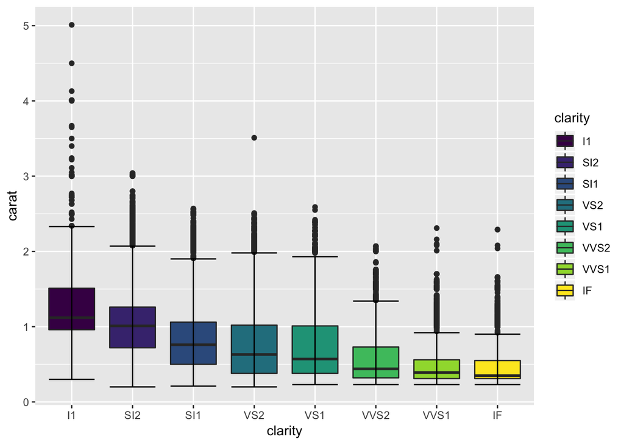

```r
ggplot(diamonds, aes(clarity, carat, fill = clarity)) +
  geom_boxplot() +
  stat_boxplot(geom = 'errorbar')
```

## QUESTION 3

### Recreate the stacked bar chart using ggplot.

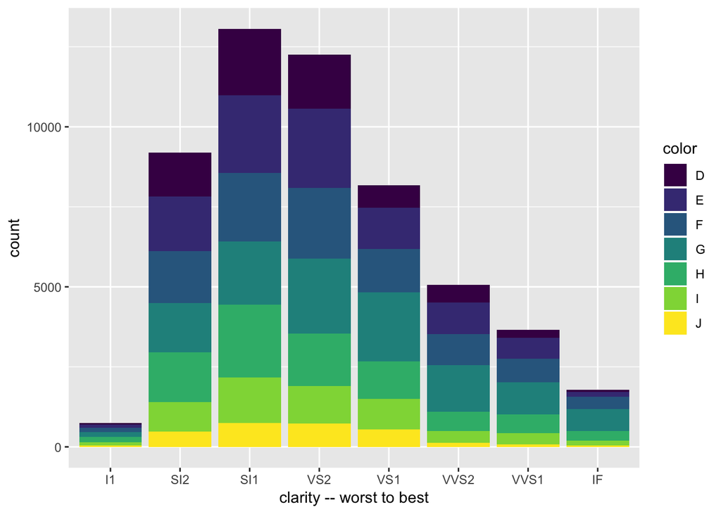

```r
ggplot(diamonds, aes(clarity, fill = color)) +
  geom_bar() +
  xlab('clarity -- worst to best')
```

#### ATTEMPT TWO

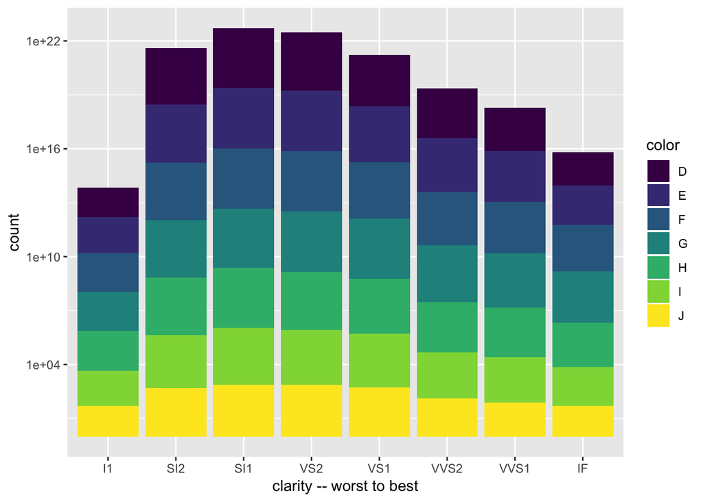

```r
ggplot(diamonds, aes(clarity, fill = color)) +
  geom_bar() +
  xlab('clarity -- worst to best') +
  scale_y_log10()
```

Clearly, this attempt didn’t help.

#### ATTEMPT THREE

ASIDE: Professor, I have no idea what I did here but this looks interesting. WHAT DOES IT MEAN?! WHAT DID I DO!? Also, I definitely don’t want Nans produced…

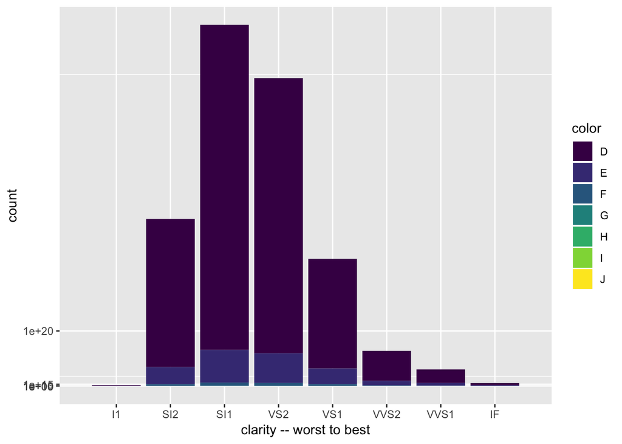

```r
pow10 <- scales::exp_trans(2)
ggplot(diamonds, aes(clarity, fill = color)) +
  geom_bar() +
  xlab('clarity -- worst to best') +
  scale_y_log10() +
  coord_trans(y= pow10)
```

#### ATTEMPT FOUR

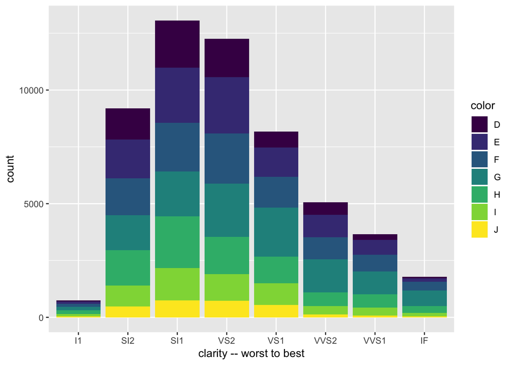

```r
ggplot(diamonds, aes(clarity, fill = color)) +
  geom_bar() +
  xlab('clarity -- worst to best') +
  expand_limits(color = factor(seq(2, 10, by = 2)))
```

Looks identical to the original chart – clearly I have no idea what expand_limits with factor is really doing.

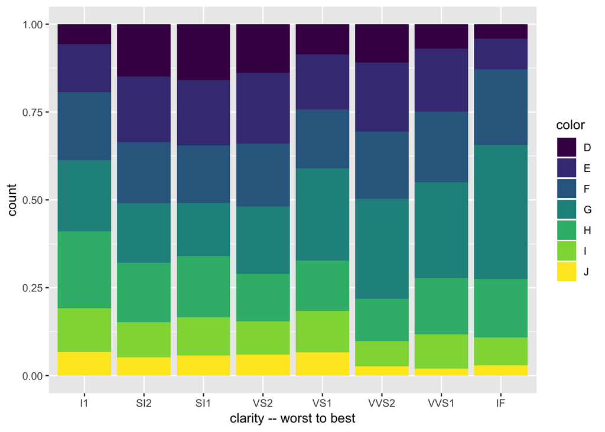

```r
ggplot(diamonds, aes(clarity, fill = color)) +
  geom_bar(position = "fill") +
  xlab('clarity -- worst to best')
```

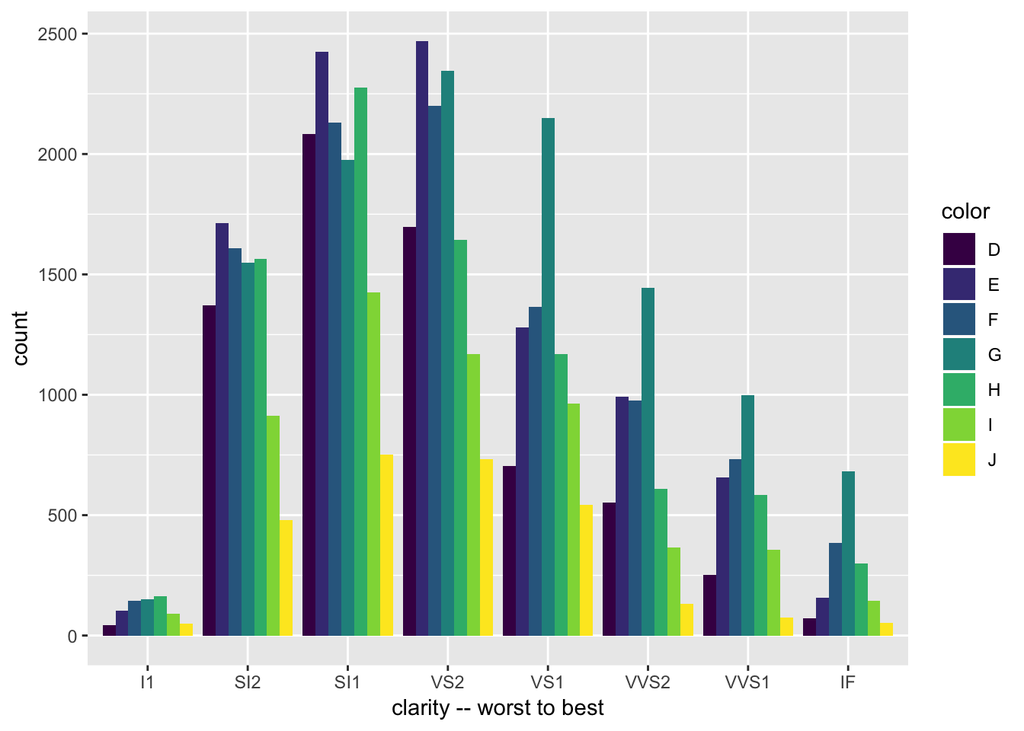

```r
ggplot(diamonds, aes(clarity, fill = color)) +
  geom_bar(position = "dodge") +
  xlab('clarity -- worst to best')
```

Even though this doesn’t match the homework, it is more helpful in understanding the relationship between color and clarity.

### What does the stacked bar say about clarity and color.

Initial attempt(s) at graphing didn’t tell much of a story. Additional graphs were needed and used, however, it is unclear how much they helped answer the question. (NOTE: Honestly, I’m not sure count is the best method of answering this question. However, under the parameters of the homework question which instructed us to replicate the included graph (which used count), there appears to be a relationship, but the relationship seems more to do with quantity and availability than actual relationship.)

### Do lower clarity diamonds have good color and why?

NOTE: Color scale – D is best, J is worst Lower clarity diamonds don’t have the best color and don’t have the worst color – they have a range of the mediocre colors. There is not enough information to answer ‘why’ however, if forced to conjecture, I’d guess color impacted clarity in some way. Without knowing more about the colors (are some darker? Does dark mean cloudier?), it is misguided to make a more definite conclusion.

### Is there an association between clarity and color, why?

FIN.